# Midterm Project - Nearest Neighbours

Chiemeziem Oguayo, Rhys Leahy, Julia Jin, Patrick Junghenn

11/09/2021

## Introduction

In a span of a few months, the COVID-19 pandemic caused by the coronavirus radically transformed the lives of many and ultimately changed the way various industries, businesses, and/or sectors have functioned. Among those affected by the pandemic have been colleges universities, specifically college advancement and fundraising. As the pandemic swept the world, the higher education institutions were forced to deal with numerous issues surrounding income losses (Wealthengine). One issue was a loss of income due to virtual learning. With education and classes being remote, most on-campus housing arrangements were vacated. And due to a lack of students on campus, any activity that would’ve otherwise gained income from students being on campus was now rendered obsolete. To combat this issue, colleges have to adopt new methods of procuring funds. One method that has been cited as being effective is through adopting new donor engagement strategies (Wealthengine). Understanding which factors have driven donations in the past could help universities better target likely donors can help improve fundraising and help mitigate or recover income loss moving forward.

With that in mind, this project aimed to determine what those factors could be. To do this, a data set called “University Advancement, Donations, and Giving” was obtained from Tableau. The dataset has 3914 observations across nine variables. This dataset is limited as it does not explore various macro and micro-level variables such as environmental(political-socio) influences, endowment, population, private or public standing, type of school (undergraduate, graduate, professional) that could have helped inform our analysis. Nonetheless, insights were able to be drawn from the nine variables provided in the dataset.

# Source Data

Using the data, this project sought to determine what factors affected the amount of money donated to universities from 2010 - 2015. The donation amount will be compared across the nine variables and tested to see if a difference exists. As mentioned before, the dataset was obtained from Tableau’s sample data and required minimal preprocessing.

```r
library(readr)
donation <- read_csv("UniversityDonations.csv")
str(donation)
```

Preprocess the data. Convert the following columns to factors: Year, State, Allocation_Subcategory, College, Gift_Allocation, Major, City

```r
donation$Year <- as.factor(donation$Year)
donation$State <- as.factor(donation$State)
donation$Allocation_Subcategory <- as.factor(donation$Allocation_Subcategory)
donation$College <- as.factor(donation$College)
donation$Gift_Allocation <- as.factor(donation$Gift_Allocation)
donation$Major <- as.factor(donation$Major)
donation$City <- as.factor(donation$City)
```

### Data Dictionary

Allocation sub_category: Donor Type

AGR: College of Agriculture & Natural Science

ALM: Alumni Association

ANN: University Annual Fund

ART: College of Arts & Sciences

ATH: Athletics

BIZ: College of Business

COM: College of Communication Arts & Sciences

DIV: Diversity Fund

EDU: College of Education

ENG: College of Engineering

FCE: Faculty Chair Endowments

HON: Honors Program

ISF: In-state Scholarship Fund

LIB: University Library

MSF: Minority Scholarship Fund

MSM: Campus Museums

MUS: College of Music

NAT: College of Natural Science

NUR: College of Nursing

PAR: Parents Association

POL: College of Political Science

RCR: Campus Recreations

TST: Trustees Fund

VET: College of Veterinary Medicine

City and State: Location of the university the money was allocated to

Gift_Allocation: Form of donation/funds

Major: Department

College: Discipline

Amount: amount of money allocated

Year: year gift was allocated

Propespec.ID - Id of recipient

### Descriptive Data Analysis

First, check if there are any rows with NaN, and if so, drop them.

A brief overview of the dataset. Our target variable or y-variable here is Amount.

The minimum is 8 while the maximum is 455821.

The standard deviation is 9235 and the variance is 85282085, which are both quite large, indicating that the data points are very spread out wide from the mean, and from one another.

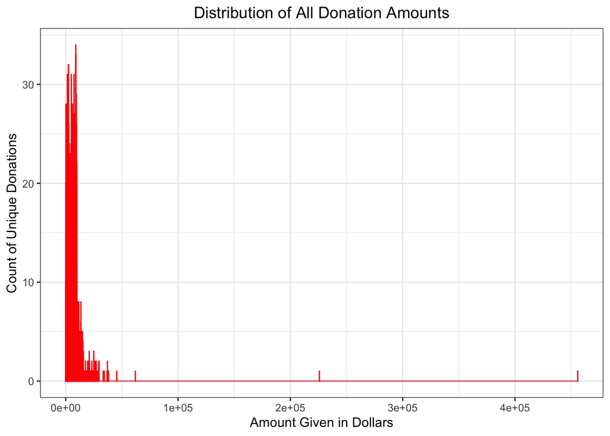

Take the log10 of donation and we will have a much cleaner graph.

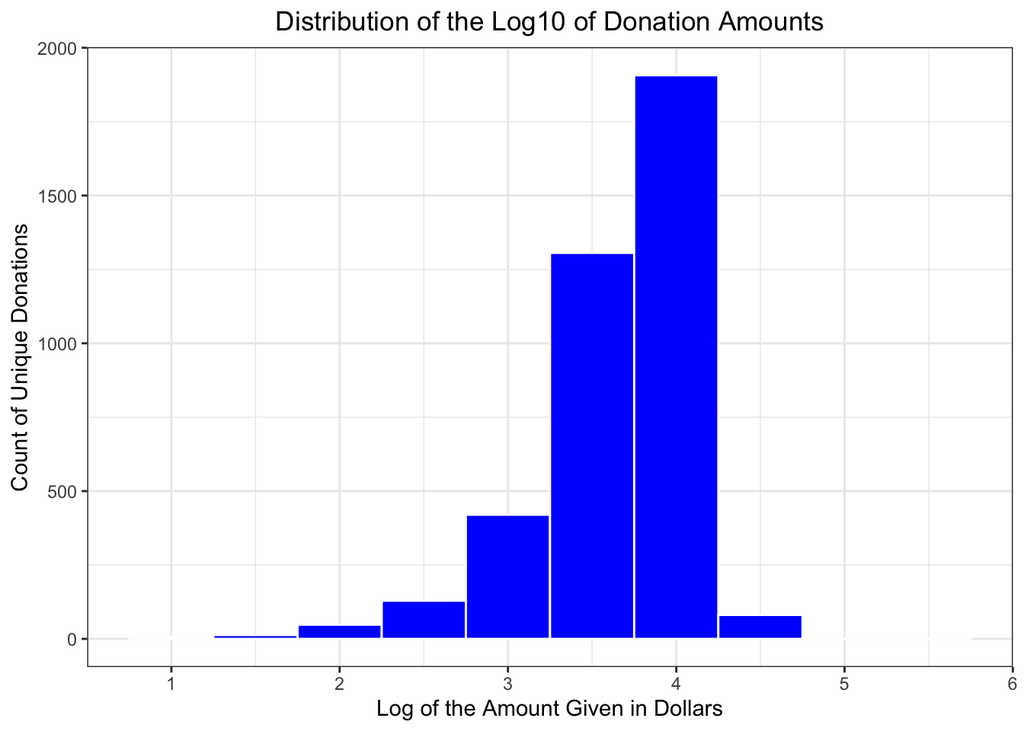

### QQ-plot

The QQ-plot indicates that most of the outliers lie on the lower end of the distribution (as you would imagine, $8).

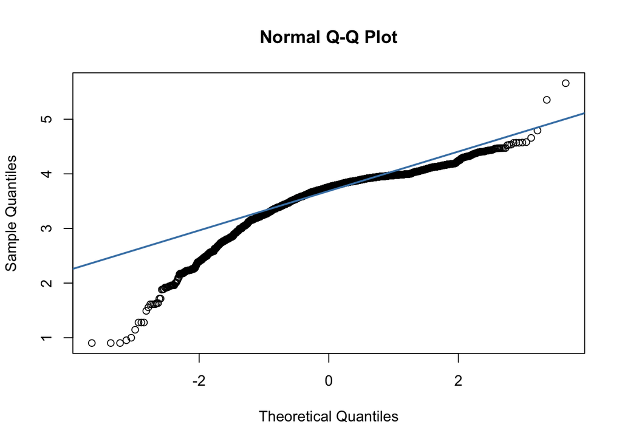

Remove any outliers before any further analysis.

Sketch a new QQ-plot without outliers.

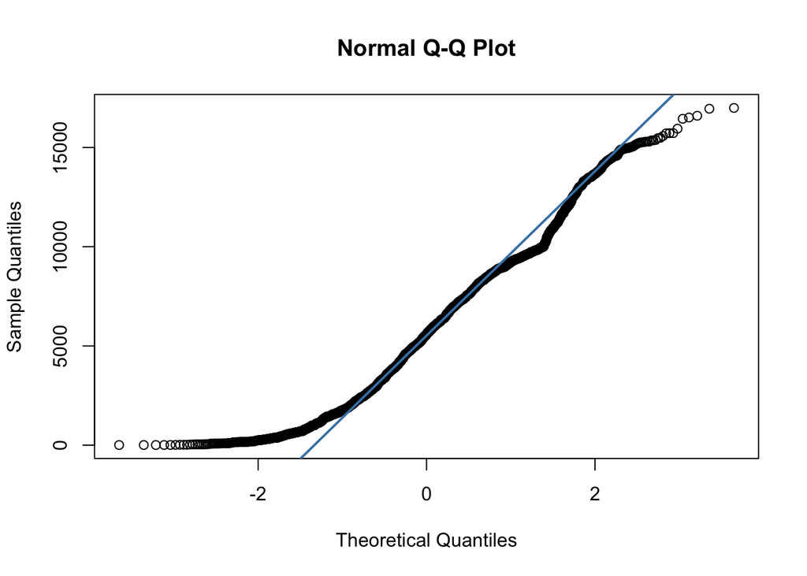

Categorize donations based on what year they are given. Further categorize donation based on allocations methods.

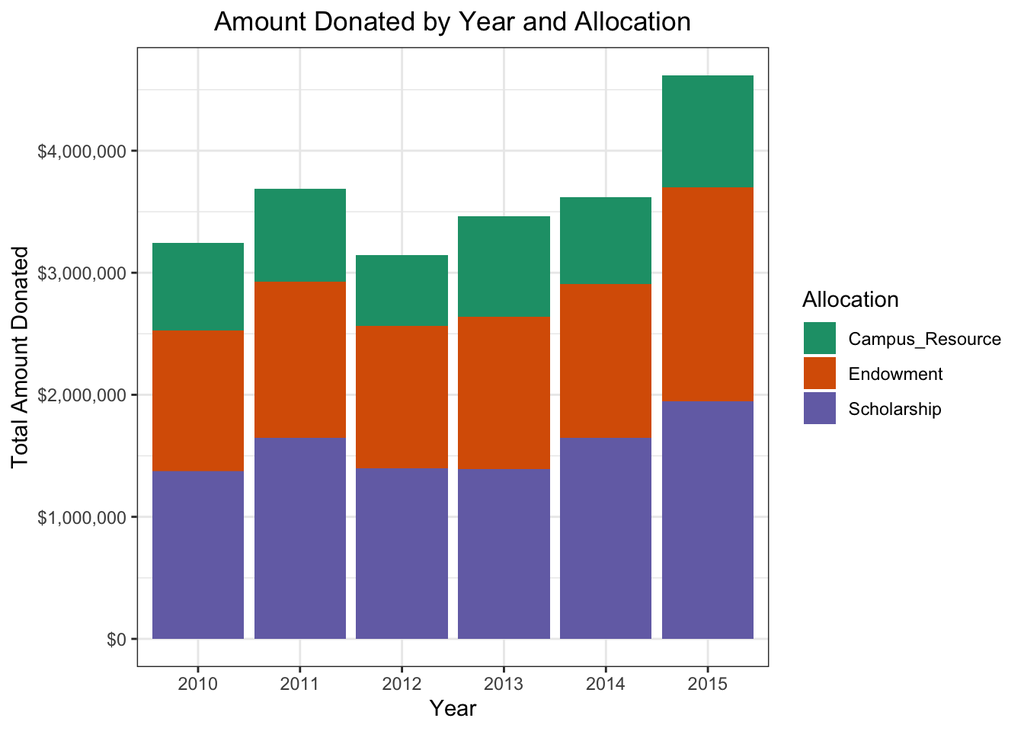

We can also categorize donation based on which college the money goes to.

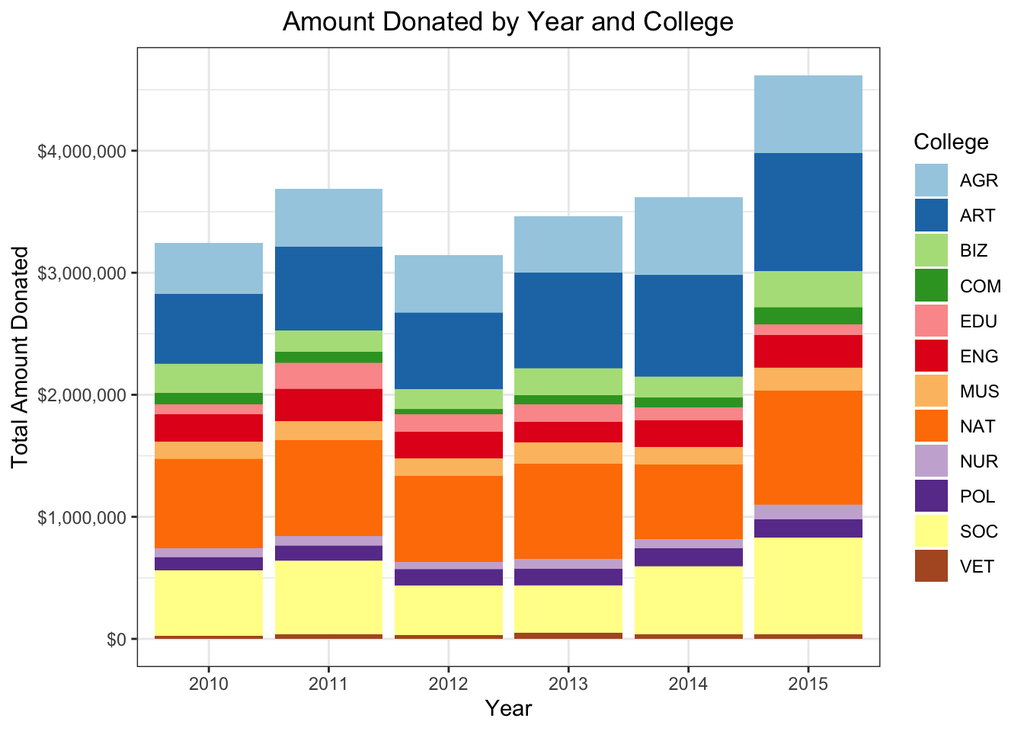

### ANOVA

SMART Question: What are the factors that affect the amount of donations received by universities in the US?

To answer our question, we will break down the data based on different features and compare the data points between each subcategory.

### vs. State

Q: Is donation the same in different states?

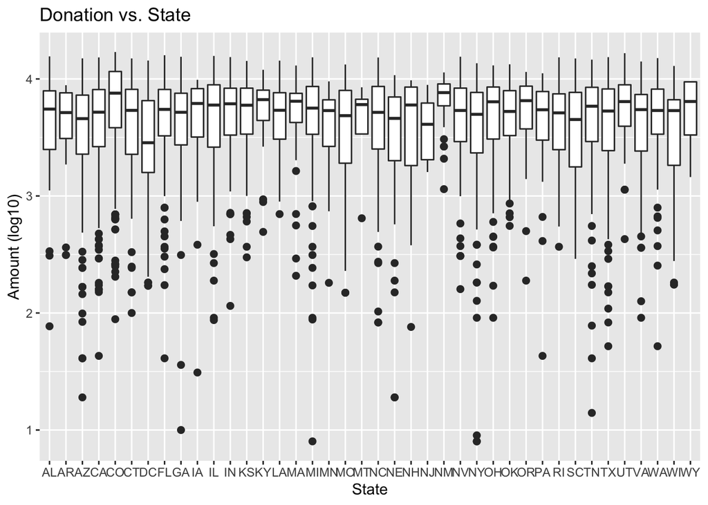

H0: The mean of donation is the same in every state.

H1: The mean of donation is different in at least one state.

As we conduct our ANOVA test, we notice that the p-value is close to 0, so we reject our null hypothesis, meaning we can say at least in one state (most likely Colorado), the mean of donation is different than in the other states, exactly what we observed from the boxplot.

### post hoc Tukey

But following pairwise comparisons have p-value smaller than the standard 0.05: NE - CO, NY - CO, TX - CO. So we can say that the mean of donation in Colorado is different from that in Nebraska, New York and Texas.

Even though the interquartile range of Wyoming also seems very different from other states, the test results states otherwise. Also notice that there are far fewer data points in this state, which could explain why the discrepancy in boxplot does not translate to the difference in mean.

### vs. College

Q: Is donation that goes to different colleges the same?

Next, let’s take a look at donation vs. colleges in a boxplot. From this visualization the interquartile range of most colleges lie in the 3.5 - 4 range, with the exception of COM, which seems lower than the rest. Additionally, the length of each box, or the value of Q3 - Q1, is about the same for all colleges.

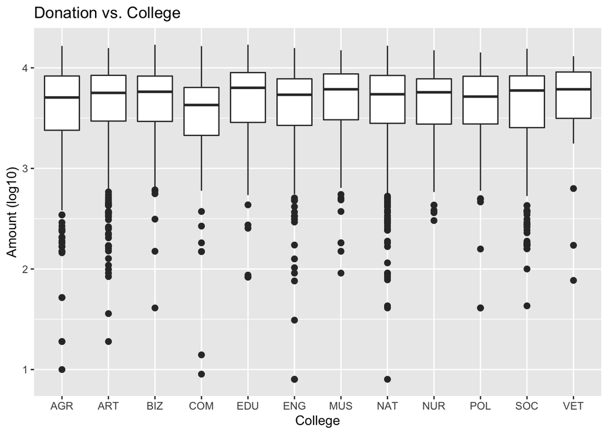

H0: The mean of donation that goes to different colleges is the same.

H1: The mean of donation that goes to different colleges are not all the same.

The p-value is 0.181 > 0.05, so we fail to reject the null hypothesis, meaning we can say the mean of donation that goes to different colleges is the same.

### vs. Year

Q: Is donation received in each year the same?

Next, let’s take a look at donation vs. years in a boxplot. From this visualization the interquartile range of each year lie in the 3.5 - 4 range. Furthermore, the value of Q3 - Q1, is about the same.

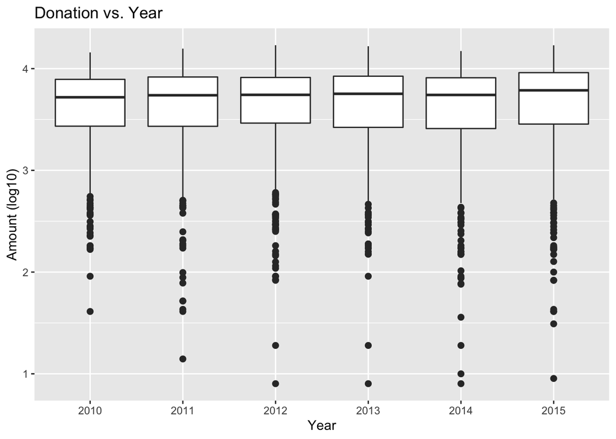

H0: The mean of donation received in each year is the same.

H1: The mean of donation received in each year are not all the same.

The p-value is 0.0925 > 0.05, so we fail to reject the null hypothesis, meaning we can say the mean of donation received in different years are the same.

### vs. Allocation

Q: Is donation with different allocation method the same?

Next, let’s take a look at donation vs. allocation in a boxplot. From this visualization the interquartile range of each allocation method lies in the 3.5 - 4 range. In addition, the value of Q3 - Q1 is about the same for each allocation method.

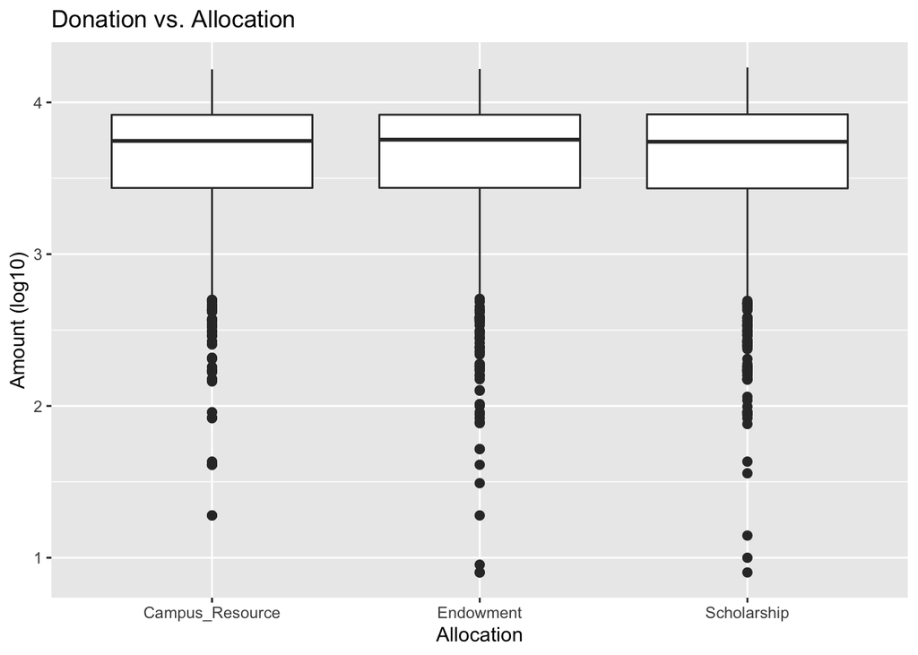

H0: The mean of donation with different allocation method is the same.

H1: The mean of donation with different allocation method are not all the same.

The p-value is 0.793 > 0.05, so we fail to reject the null hypothesis, meaning we can say the mean of donation with different allocations are the same.

Further break down each allocation method into its subcategories. Conduct ANOVA test separately on each allocation method across its subcategories.

### Campus Resources

Q: Is donation from different campus resources the same?

From this visualization, the interquartile range of each resource varies from each other. For most resources, the value of Q1 is around 3.5, except for RCR which sits far below at around 3.25. The interquartile range of RCR extends a lot further than the others, especially that of ATH. It seems like the mean of RCR could possibly be different from that of other resources.

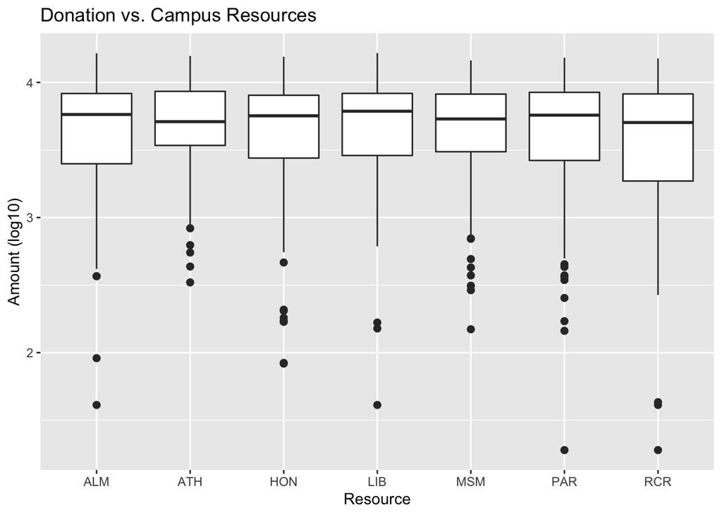

H0: The mean of donation from different campus resources is the same.

H1: The mean of donation from at least one campus resource is different from the others.

The p-value is 0.222 > 0.05, so we cannot reject our null hypothesis, meaning we can say the mean of donation among different resources are the same.

Sample size cannot explain the difference of the test result and the boxplot here; each resource has a sample size between 100 - 120, roughly the same. But notice the medians are about the same. A possible explanation is that for the data points in Q3, the data points of RCR on average have higher value than those of ATH, thus they are able to cover the lower values of data points in Q1.

### Endowment

Q: Is donation of different endowments the same?

Now, let’s take a look at donation vs. endowment in a boxplot. From this visualization the interquartile range of each year lie in the same range. Furthermore, the interquartile range of each box is about the same.

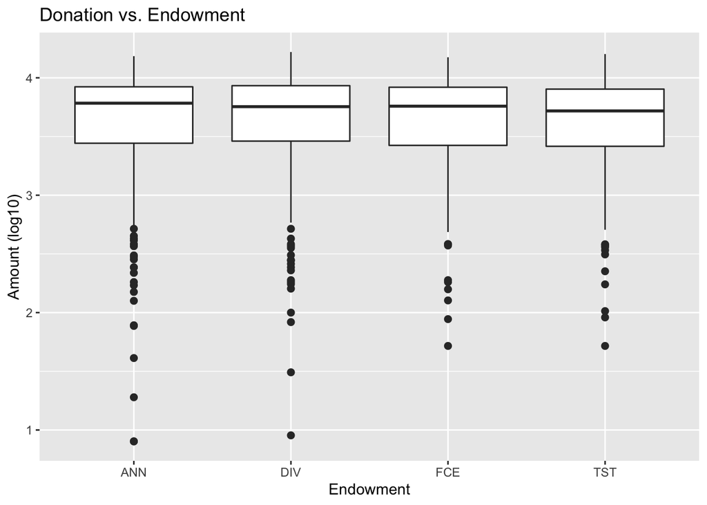

H0: The mean of donation of different endowments the same.

H1: The mean of donation of at least one endowment is different from the others.

The p-value is 0.850 > 0.05, so we cannot reject our null hypothesis, meaning we can say the mean of donation among different endowments are the same.

### Scholarship

Q: Is donation from different scholarships the same?

Finally let’s look at donation vs. scholarship in a boxplot.

From this visualization, the interquartile of different scholarships varies a lot. The value of Q1 can go as low as 3.3 (AGR, ENG) and can be as high as 3.55 (NUR). Since the value of Q3 is about the same at 3.9, the interquartile range expands differently among various scholarships. Also notice here, the medians do not lie around the same level with NUR having the highest at 3.8 and VET having the lowest at 3.55.

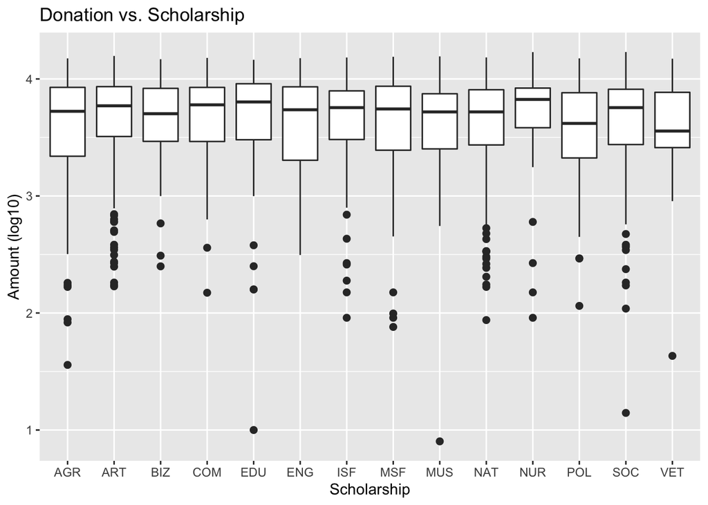

H0: The donation from different scholarships the same.

H1: The donation from at least one scholarships is different than the others.

The p-value is 0.677 > 0.05, so we cannot reject our null hypothesis, meaning we can say the mean of donation among different resources is the same.

Difference in sample size is the likely explanation behind the discrepancy of the observation in boxplot and the test result. NUR has the smallest sample size of 32 whereas NAT has the largest of 307.

### ANOVA for all

There is only one numeric variable, ‘amount’, so cant use two sided t tests.

```r
anova_all <- aov(log10(Amount) ~ Gift_Allocation + Allocation_Subcategory + City +
                   College + Year + Major + State, data = donation2)
summary.aov(anova_all)
```

```
##                          Df Sum Sq Mean Sq F value  Pr(>F)
## Gift_Allocation           2      0   0.045    0.24    0.79
## Allocation_Subcategory   22      4   0.170    0.91    0.58
## City                     94     37   0.396    2.11 3.7e-09 ***
## College                  11      3   0.251    1.34    0.19
## Year                      5      2   0.319    1.70    0.13
## Major                   108     22   0.200    1.07    0.30
## State                     2      0   0.130    0.69    0.50
## Residuals              3577    669   0.187
## ---
## Signif. codes:  0 '***' 0.001 '**' 0.01 '*' 0.05 '.' 0.1 ' ' 1
## 91 observations deleted due to missingness
```